# Brewing Insights: Cleaning, Exploring, and Analyzing 10,000 Messy Cafe Sales Records to Drive Business Strategy

Moshood A. Garuba

2025-05-03

# Project Goal:

To clean and analyze messy transactional sales data from The Dirty Cafe to uncover customer behavior, top-selling items, revenue trends, and operational inefficiencies. Ultimately, the analysis will inform data-driven decisions to increase revenue, optimize inventory, and enhance customer experience.

# Narrative & Structure:

## 1. Introduction / Business Background:

The Dirty Cafe is a fast-growing urban café chain with multiple outlets. Recently, the café started recording digital sales, but data entry issues and inconsistent systems have introduced messiness into the dataset. As a data analyst, you’re tasked with transforming the raw data into actionable business insights to support growth.

```r
# Load required libraries
library(tidyverse)
library(lubridate)
library(readr)
library(janitor)
library(dplyr)
library(kableExtra)
library(naniar)
library(lubridate)
library(dlookr)
library(patchwork)
library(gt)
library(gtsummary)
library(report)

# Read the CSV
cafe_data <- read_csv("dirty_cafe_sales.csv")
```

## 2. Data Cleaning:

```r
#Checking the names of the variables
names(cafe_data)
```

```
## [1] "Transaction ID"   "Item"             "Quantity"         "Price Per Unit"
## [5] "Total Spent"      "Payment Method"   "Location"         "Transaction Date"
```

```r
# Checking the structure of the variables
glimpse(cafe_data)
```

```
## Rows: 10,000
## Columns: 8
## $ `Transaction ID`   <chr> "TXN_1961373", "TXN_4977031", "TXN_4271903", "TXN_7…
## $ Item               <chr> "Coffee", "Cake", "Cookie", "Salad", "Coffee", "Smo…
## $ Quantity           <chr> "2", "4", "4", "2", "2", "5", "3", "4", "5", "5", "…
## $ `Price Per Unit`   <chr> "2.0", "3.0", "1.0", "5.0", "2.0", "4.0", "3.0", "4…
## $ `Total Spent`      <chr> "4.0", "12.0", "ERROR", "10.0", "4.0", "20.0", "9.0…
## $ `Payment Method`   <chr> "Credit Card", "Cash", "Credit Card", "UNKNOWN", "D…
## $ Location           <chr> "Takeaway", "In-store", "In-store", "UNKNOWN", "In-…
## $ `Transaction Date` <chr> "2023-09-08", "2023-05-16", "2023-07-19", "2023-04-…
```

```r
# Checking the number of rows and columns
dim(cafe_data)
```

```
## [1] 10000     8
```

```r
# Getting the head of the data
head(cafe_data) %>% kable()
```

| Transaction ID | Item | Quantity | Price Per Unit | Total Spent | Payment Method | Location | Transaction Date |
| --- | --- | --- | --- | --- | --- | --- | --- |
| TXN_1961373 | Coffee | 2 | 2.0 | 4.0 | Credit Card | Takeaway | 2023-09-08 |
| TXN_4977031 | Cake | 4 | 3.0 | 12.0 | Cash | In-store | 2023-05-16 |
| TXN_4271903 | Cookie | 4 | 1.0 | ERROR | Credit Card | In-store | 2023-07-19 |
| TXN_7034554 | Salad | 2 | 5.0 | 10.0 | UNKNOWN | UNKNOWN | 2023-04-27 |
| TXN_3160411 | Coffee | 2 | 2.0 | 4.0 | Digital Wallet | In-store | 2023-06-11 |
| TXN_2602893 | Smoothie | 5 | 4.0 | 20.0 | Credit Card | NA | 2023-03-31 |

```r
# Getting the tail of the data

tail(cafe_data) %>% kable()
```

| Transaction ID | Item | Quantity | Price Per Unit | Total Spent | Payment Method | Location | Transaction Date |
| --- | --- | --- | --- | --- | --- | --- | --- |
| TXN_7851634 | UNKNOWN | 4 | 4.0 | 16.0 | NA | NA | 2023-01-08 |
| TXN_7672686 | Coffee | 2 | 2.0 | 4.0 | NA | UNKNOWN | 2023-08-30 |
| TXN_9659401 | NA | 3 | NA | 3.0 | Digital Wallet | NA | 2023-06-02 |
| TXN_5255387 | Coffee | 4 | 2.0 | 8.0 | Digital Wallet | NA | 2023-03-02 |
| TXN_7695629 | Cookie | 3 | NA | 3.0 | Digital Wallet | NA | 2023-12-02 |
| TXN_6170729 | Sandwich | 3 | 4.0 | 12.0 | Cash | In-store | 2023-11-07 |

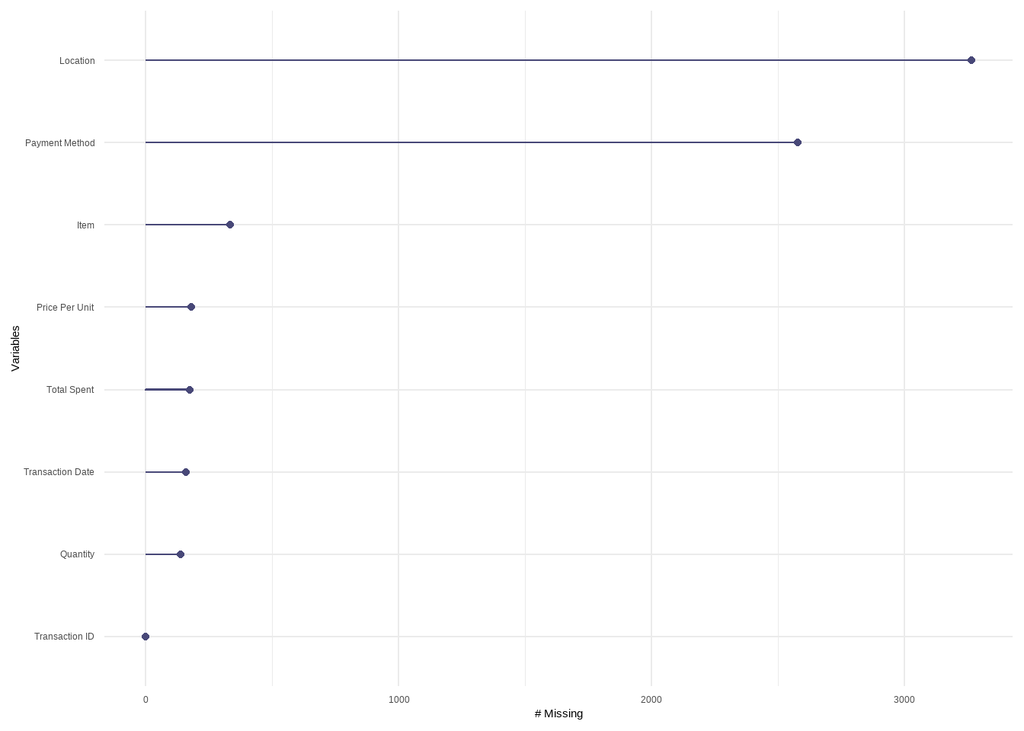

```r
#Visualizing missing data
gg_miss_var(cafe_data)
```

```r
#Calculating the total missing data

sum(!complete.cases(cafe_data))
```

```
## [1] 5450
```

```r
#Fixing data problem

cafe_data_cleaned <- cafe_data %>%
  mutate(
    Quantity = as.numeric(Quantity),
    `Price Per Unit` = as.numeric(`Price Per Unit`),
    `Total Spent` = as.numeric(`Total Spent`),
    `Transaction Date` = as.Date(`Transaction Date`)
  ) %>%
  mutate(across(where(is.character), str_to_sentence))
```

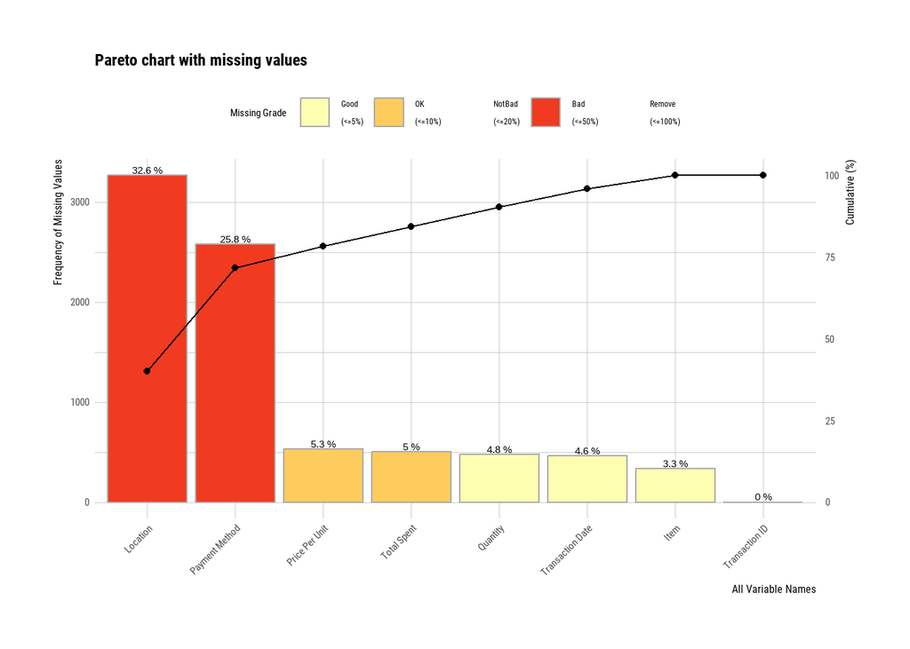

```r
plot_na_pareto(cafe_data_cleaned)
```

**We have a large number of Na which is very bad strategy for us to remove them, we need to fill the NA with tag call missing so that we can make account for them**

```r
#replace "Na" with the tag "missing"
cafe_data_cleaned<- cafe_data_cleaned %>%
  mutate(across(where(is.character), ~ replace_na(., "Missing")))

str(cafe_data_cleaned)
```

```
## tibble [10,000 × 8] (S3: tbl_df/tbl/data.frame)
##  $ Transaction ID  : chr [1:10000] "Txn_1961373" "Txn_4977031" "Txn_4271903" "Txn_7034554" ...
##  $ Item            : chr [1:10000] "Coffee" "Cake" "Cookie" "Salad" ...
##  $ Quantity        : num [1:10000] 2 4 4 2 2 5 3 4 5 5 ...
##  $ Price Per Unit  : num [1:10000] 2 3 1 5 2 4 3 4 3 4 ...
##  $ Total Spent     : num [1:10000] 4 12 NA 10 4 20 9 16 15 20 ...
##  $ Payment Method  : chr [1:10000] "Credit card" "Cash" "Credit card" "Unknown" ...
##  $ Location        : chr [1:10000] "Takeaway" "In-store" "In-store" "Unknown" ...
##  $ Transaction Date: Date[1:10000], format: "2023-09-08" "2023-05-16" ...
```

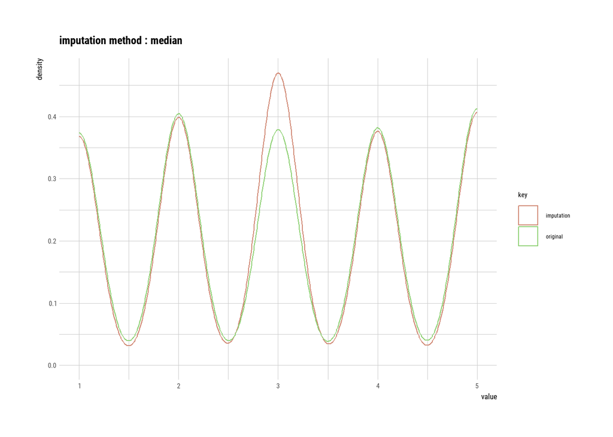

```r
# We are trying to iterate a better method for imputing the missing values for Quantity
imputate_na(cafe_data_cleaned,Quantity,method = "median") %>% plot()
```

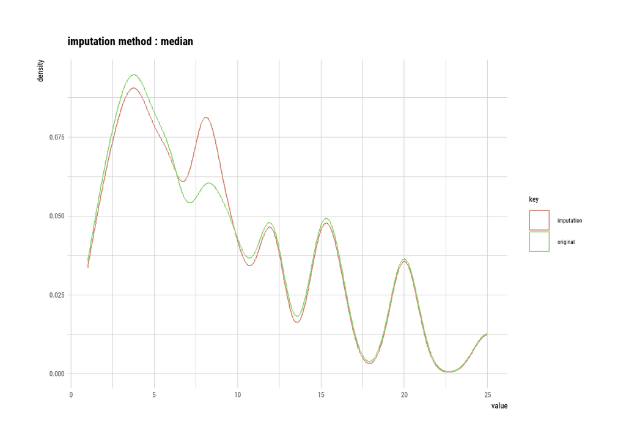

```r
#imputate_na(cafe_data_cleaned,Quantity,method = "mean") %>% plot()
#imputate_na(cafe_data_cleaned,Quantity,method = "mode") %>% plot()

#For Total spent
imputate_na(cafe_data_cleaned,`Total Spent`,method = "median") %>% plot()
```

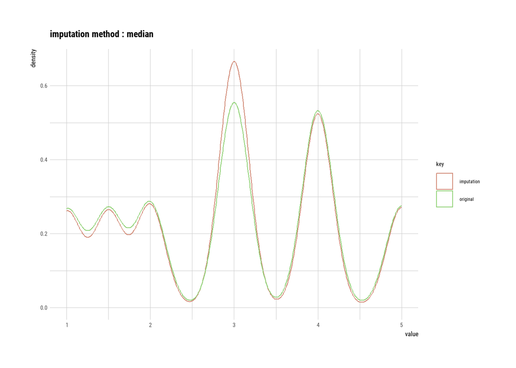

```r
#imputate_na(cafe_data_cleaned,`Total Spent`,method = "mean") %>% plot()
#imputate_na(cafe_data_cleaned,`Total Spent`,method = "mode") %>% plot()

#For Price Per Unit
imputate_na(cafe_data_cleaned,`Price Per Unit`,method = "median") %>% plot()
```

```r
#imputate_na(cafe_data_cleaned,`Price Per Unit`,method = "mean") %>% plot()
#imputate_na(cafe_data_cleaned,`Price Per Unit`,method = "mode") %>% plot()

cafe_data_cleaned<- cafe_data_cleaned %>%
  mutate(Quantity = imputate_na(cafe_data_cleaned,Quantity,method = "median"),
         `Total Spent` = imputate_na(cafe_data_cleaned,`Total Spent`,method = "median"),
         `Price Per Unit` = imputate_na(cafe_data_cleaned,`Price Per Unit`,method = "median"))
```

# 3. Exploratory Data Analysis (EDA)

## Descriptive Analysis of Quantity, Price Per Unit and Total Spent.

```r
cafe_data_cleaned %>%
  select(Quantity, `Price Per Unit`, `Total Spent`) %>%
  summarise(across(everything(),
                   .fns = list(
                     min = ~min(.x, na.rm = TRUE),
                     median = ~median(.x, na.rm = TRUE),
                     average = ~mean(.x, na.rm = TRUE)
                   ))) %>%
  pivot_longer(cols = everything(),
               names_to = c("Variable", "Statistic"),
               names_sep = "_",
               values_to = "Value") %>%  kable()
```

| Variable | Statistic | Value |
| --- | --- | --- |
| Quantity | min | 1.00000 |
| Quantity | median | 3.00000 |
| Quantity | average | 3.02710 |
| Price Per Unit | min | 1.00000 |
| Price Per Unit | median | 3.00000 |
| Price Per Unit | average | 2.95265 |
| Total Spent | min | 1.00000 |
| Total Spent | median | 8.00000 |
| Total Spent | average | 8.87795 |

## What are the Item distribution?

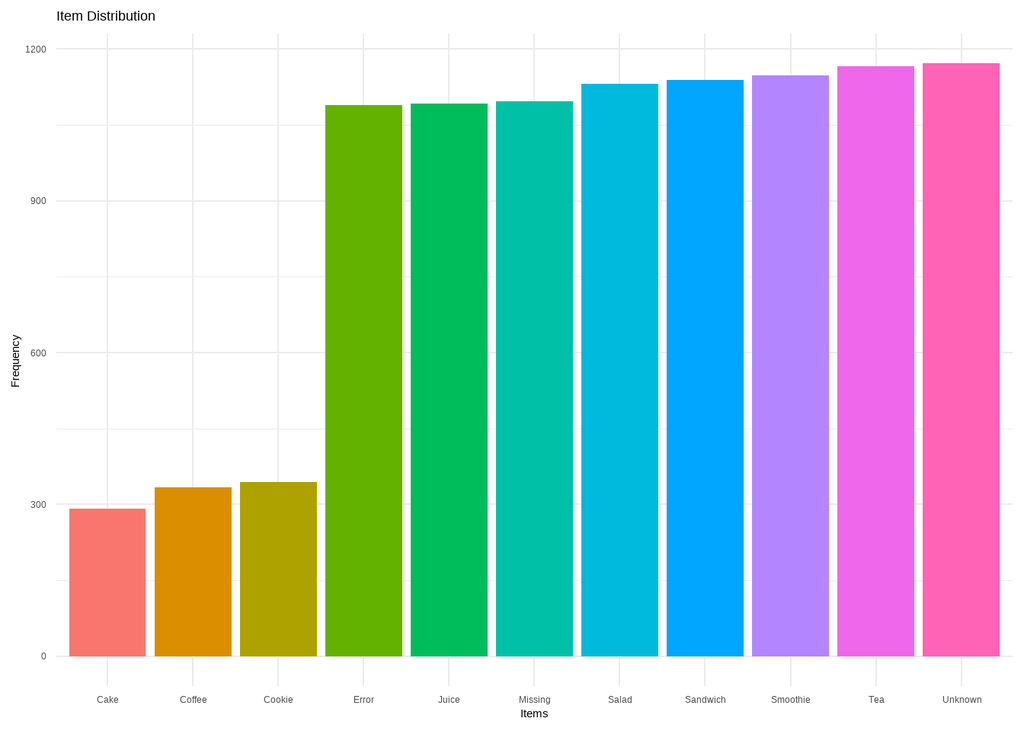

```r
cafe_data_cleaned %>%
  group_by(Item) %>%
  summarise(n = n()) %>%
  ggplot(aes(x = Item, y = sort(n)))+
  geom_bar(stat = "Identity", aes(fill = Item),
           show.legend = F)+
  labs(title = "Item Distribution", x = "Items", y = "Frequency")+
  theme_minimal()
```

## What are the items sold by quantity and revenue?

```r
cafe_data_cleaned %>%
  group_by(Item) %>%
  summarise(
    `Total Quantity` = sum(Quantity, na.rm = TRUE),
    `Total Revenue` = sum(`Total Spent`, na.rm = TRUE)
  ) %>%
  top_n(n = 10, wt = `Total Revenue`) %>% kable()
```

| Item | Total Quantity | Total Revenue |
| --- | --- | --- |
| Cake | 3467 | 10341.0 |
| Coffee | 3551 | 7184.0 |
| Cookie | 3249 | 3526.0 |
| Juice | 3514 | 10432.0 |
| Missing | 1016 | 3017.0 |
| Salad | 3469 | 17021.0 |
| Sandwich | 3428 | 13484.0 |
| Smoothie | 3353 | 13132.0 |
| Tea | 3319 | 5119.5 |
| Unknown | 1006 | 2933.5 |

```r
cafe_data_cleaned %>%
  group_by(`Payment Method`) %>%
  summarise(n = n()) %>%
  arrange(n) %>% kable()
```

| Payment Method | n |
| --- | --- |
| Unknown | 293 |
| Error | 306 |
| Cash | 2258 |
| Credit card | 2273 |
| Digital wallet | 2291 |
| Missing | 2579 |

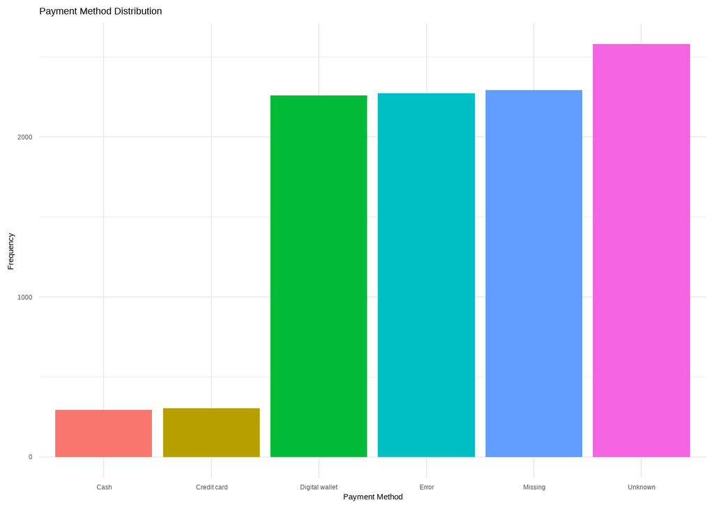

```r
cafe_data_cleaned %>%
  group_by(`Payment Method`) %>%
  summarise(n = n()) %>%
  ggplot(aes( x = `Payment Method`, y = sort(n)))+
  geom_bar(aes(fill = `Payment Method`), stat = "Identity", show.legend = F)+
  labs(title = "Payment Method Distribution", y = "Frequency")+
  theme_minimal()
```

## Total Amount Spent

```r
cafe_data_cleaned %>%
  group_by(Item) %>%
  summarise(n = n(),
            Total = sum(`Total Spent`),
            `Average Amount Spent` = round(mean(`Total Spent`),2)) %>%
  arrange(n) %>% kable()
```

| Item | n | Total | Average Amount Spent |
| --- | --- | --- | --- |
| Error | 292 | 2589.5 | 8.87 |
| Missing | 333 | 3017.0 | 9.06 |
| Unknown | 344 | 2933.5 | 8.53 |
| Tea | 1089 | 5119.5 | 4.70 |
| Cookie | 1092 | 3526.0 | 3.23 |
| Smoothie | 1096 | 13132.0 | 11.98 |
| Sandwich | 1131 | 13484.0 | 11.92 |
| Cake | 1139 | 10341.0 | 9.08 |
| Salad | 1148 | 17021.0 | 14.83 |
| Coffee | 1165 | 7184.0 | 6.17 |
| Juice | 1171 | 10432.0 | 8.91 |

```r
cafe_data_cleaned %>%
  group_by(Location) %>%
  summarise(n = n(),
            `Total Quantity` = sum(Quantity),
            `Average Quantity` = round(mean(Quantity),2)) %>% kable()
```

| Location | n | Total Quantity | Average Quantity |
| --- | --- | --- | --- |
| Error | 358 | 1100 | 3.07 |
| In-store | 3017 | 9139 | 3.03 |
| Missing | 3265 | 9893 | 3.03 |
| Takeaway | 3022 | 9176 | 3.04 |
| Unknown | 338 | 963 | 2.85 |

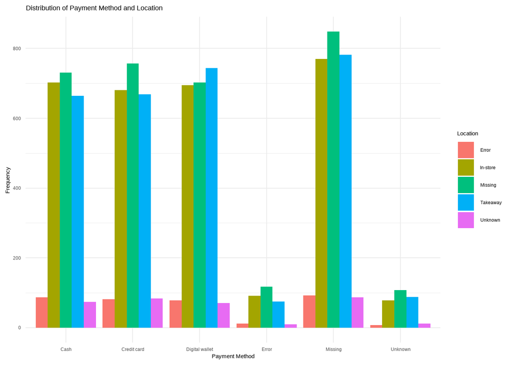

```r
cafe_data_cleaned %>%
  group_by(`Payment Method`,Location) %>%
  summarise(n = n()) %>%
  ggplot(aes( x= `Payment Method`, y = n))+
  geom_bar(aes(fill = Location), stat = "identity",
           position = "dodge")+
  labs(title = "Distribution of Payment Method and Location",
       y = "Frequency")+
  theme_minimal()
```

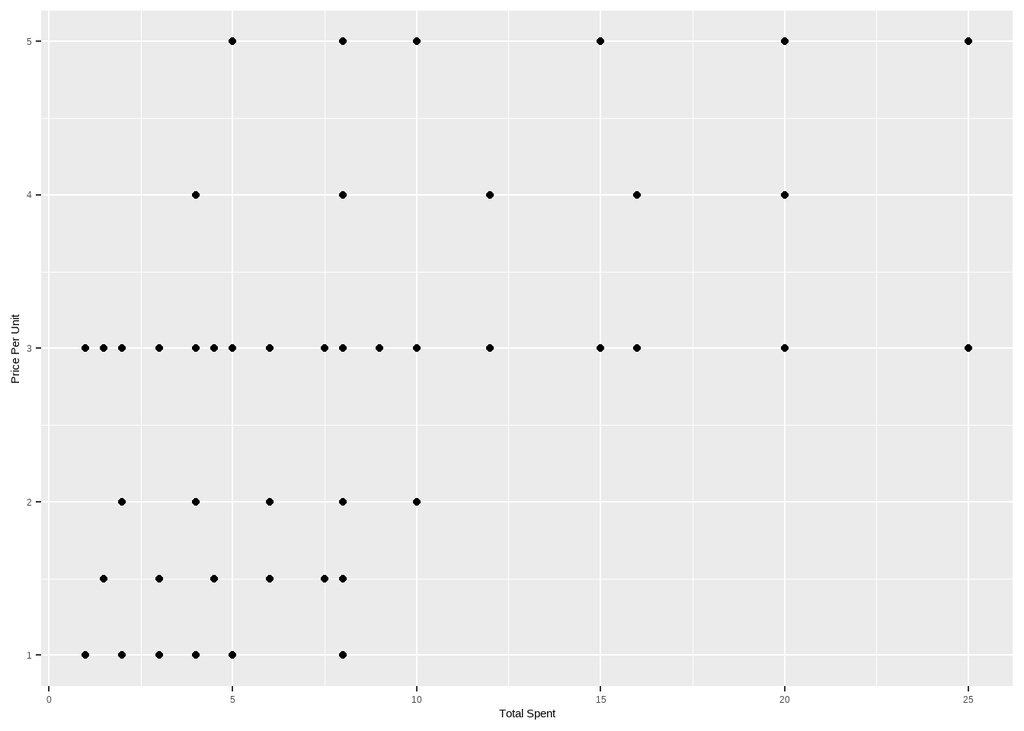

```r
cafe_data_cleaned %>%
  ggplot(aes(x = `Total Spent`, y = `Price Per Unit`))+
  geom_point()
```

# Modeling and Inference

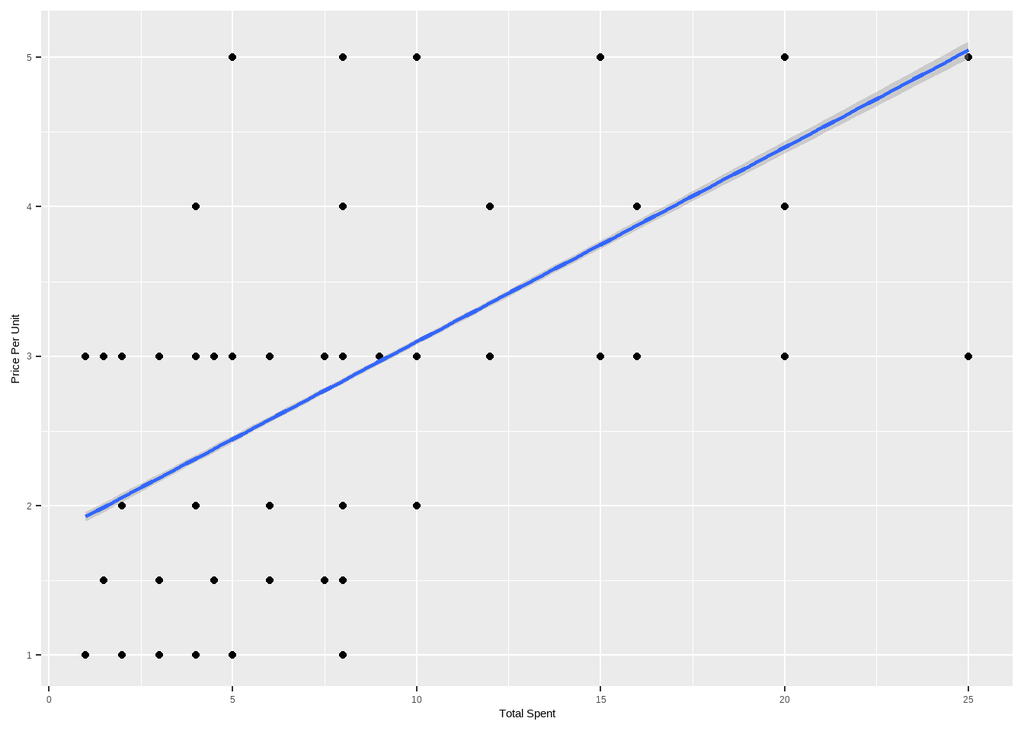

```r
cafe_data_cleaned %>%
  ggplot(aes(x = `Total Spent`, y = `Price Per Unit`))+
  geom_point()+
  geom_smooth(method = "lm")
```

```r
model<- lm(Quantity~`Price Per Unit`, data = cafe_data_cleaned)

summary(model)
```

```
##
## Call:
## lm(formula = Quantity ~ `Price Per Unit`, data = cafe_data_cleaned)
##
## Residuals:
##      Min       1Q   Median       3Q      Max
## -2.04057 -1.02741 -0.02741  0.97917  1.98575
##
## Coefficients:
##                  Estimate Std. Error t value Pr(>|t|)
## (Intercept)      3.007668   0.035665  84.330   <2e-16 ***
## `Price Per Unit` 0.006581   0.011132   0.591    0.554
## ---
## Signif. codes:  0 '***' 0.001 '**' 0.01 '*' 0.05 '.' 0.1 ' ' 1
##
## Residual standard error: 1.385 on 9998 degrees of freedom
## Multiple R-squared:  3.496e-05,  Adjusted R-squared:  -6.506e-05
## F-statistic: 0.3496 on 1 and 9998 DF,  p-value: 0.5544
```

# Conclusion

This project explored the full data science workflow using the Dirty Cafe Sales dataset — a realistically messy dataset containing 10,000 café transactions. Through rigorous data cleaning, including handling missing values, correcting inconsistent formatting, and converting variables to appropriate types, we transformed a chaotic dataset into a reliable source for analysis.

We then conducted exploratory data analysis (EDA), uncovering key business insights such as the most popular items, highest revenue-generating products, and patterns in purchasing behavior. Summary statistics helped describe central trends in spending, while visualizations and group-level aggregations highlighted the café’s top-performing offerings.

Overall, this project showcased the importance of data cleaning as a foundational step in the data science process, and demonstrated how even initially unreliable data can yield valuable insights when properly wrangled. These insights can be used to guide business decisions, optimize inventory, and tailor marketing strategies to customer preferences.